# Отчёт по прохождению 1 этапа внешнего курса

Введение

Автор

принадлежность

Терентеевская Светлана Александровна, Student

Российский университет дружбы народов

Дата публикации

2026-05-10

# Информация

## Докладчик

- Терентеевская Светлана Александровна
- Группа НКАбд-05-25, студент бакалавра
- Российский университет дружбы народов им. П. Лумумбы
- 1032253498@rudn.ru
- https://github.com/SvetlanaTerenteevskaya # Вводная часть

## Цель работы

Пройти 1 этапа курса “Введение в Linux” на платформе Stepik и ознакомиться с функционалом Linux.

## Задание

Просмотреть обучающие видео и на основе полученной информации пройти тестовые и интерактивные задание

## Теоретическое введение

Линукс - в части случаев GNU/Linux — семейство Unix-подобных операционных систем на базе ядра Linux, включающих тот или иной набор утилит и программ проекта GNU, и, возможно, другие компоненты. Как и ядро Linux, системы на его основе, как правило, создаются и распространяются в соответствии с моделью разработки свободного и открытого программного обеспечения. Linux-системы распространяются в основном бесплатно в виде различных дистрибутивов — в форме, готовой для установки и удобной для сопровождения и обновлений, — и имеющих свой набор системных и прикладных компонентов, как свободных, так и проприетарных.

# Прохождение внешнего курса

Название внешнего курса “Введение в Linux” (рис. 1).

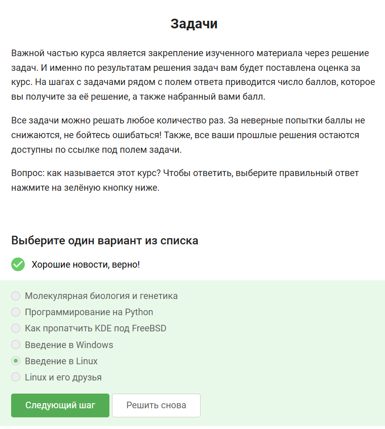

Рисунок 1: 1 задание

Я ознакомилась с критериями и выбрала подходящие (рис. 2).

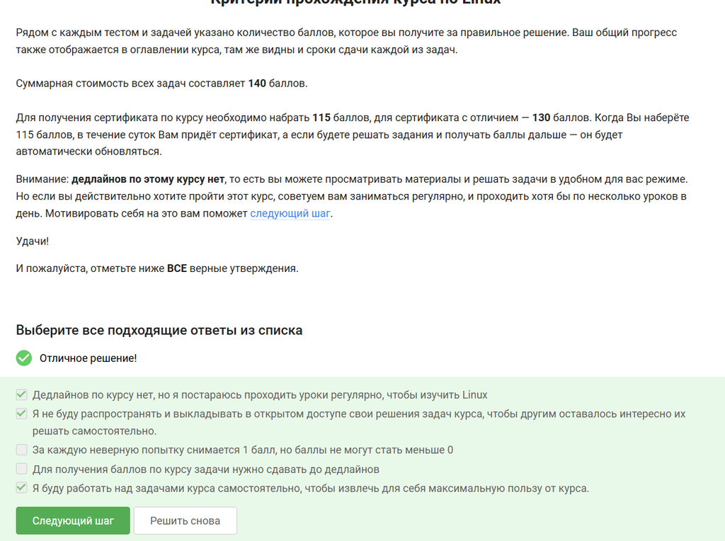

Рисунок 2: 2 задание

Я пользуюсь 2 операционными системами: Linux и Windows (рис. 3).

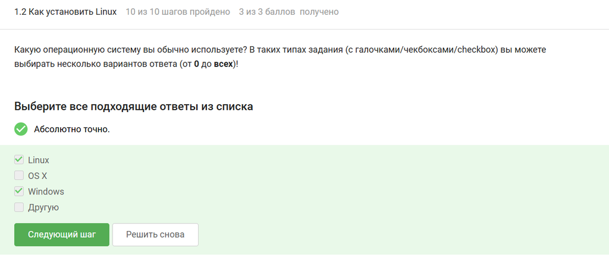

Рисунок 3: 3 задание

На компьютер мы устанавливаем VirtualBox, которая является специальной программой для запуска одной ОС на другой ОС, соответственно виртуальной машиной (рис. 4).

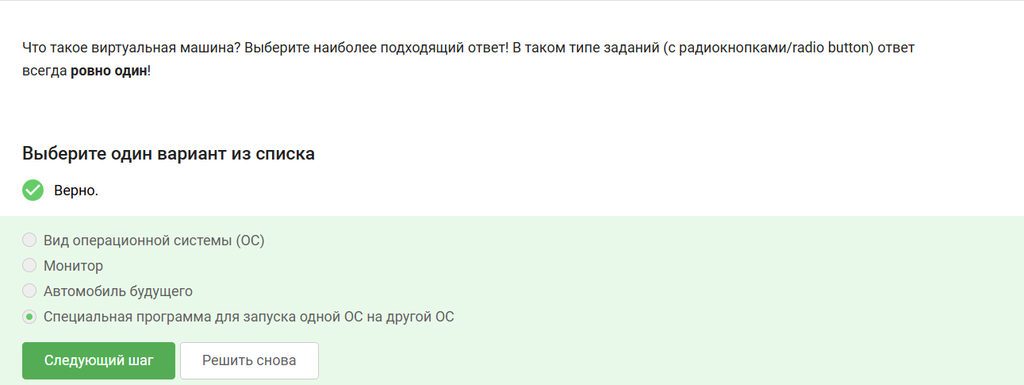

Рисунок 4: 4 задание

У меня получилось успешно запустить виртуальную машину с Linux на моем компьютере (рис. 5).

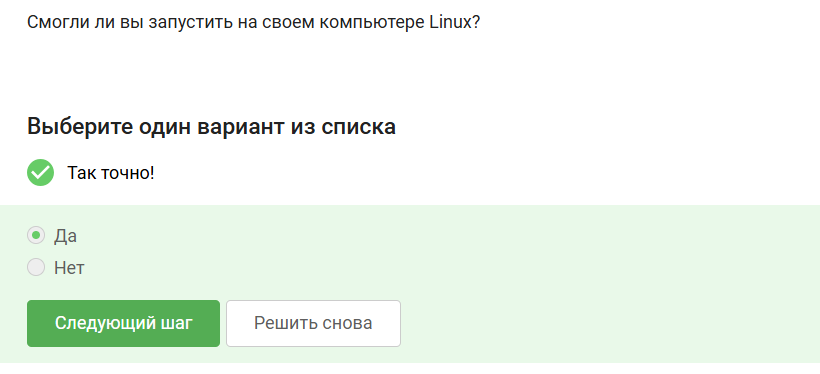

Рисунок 5: 5 задание

Я создала документ в LibreOffice и написала в нем “Hello, Linux” (рис. 6).

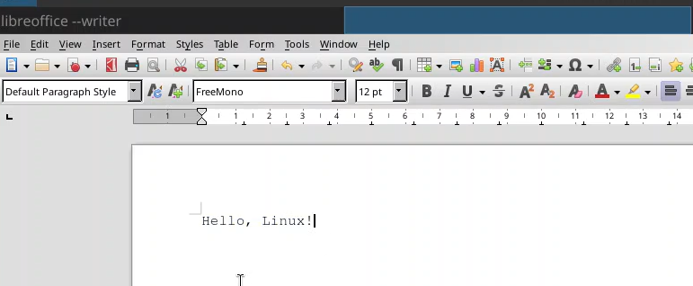

Рисунок 6: 6 задание

Загрузила на Stepik (рис. 7).

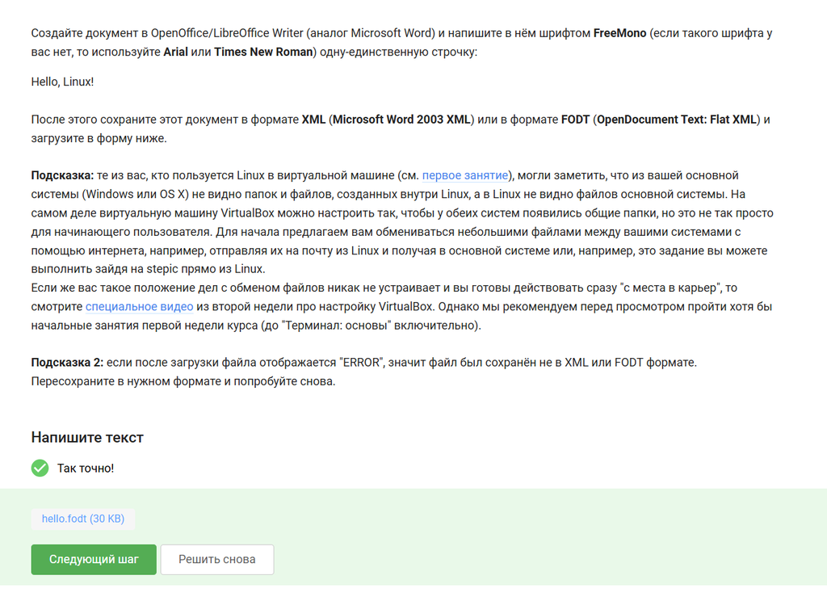

Рисунок 7: 6 задание

deb - формат пакетов ОС проекта Debian. Используется их производными, например Ubuntu и другими (рис. 8).

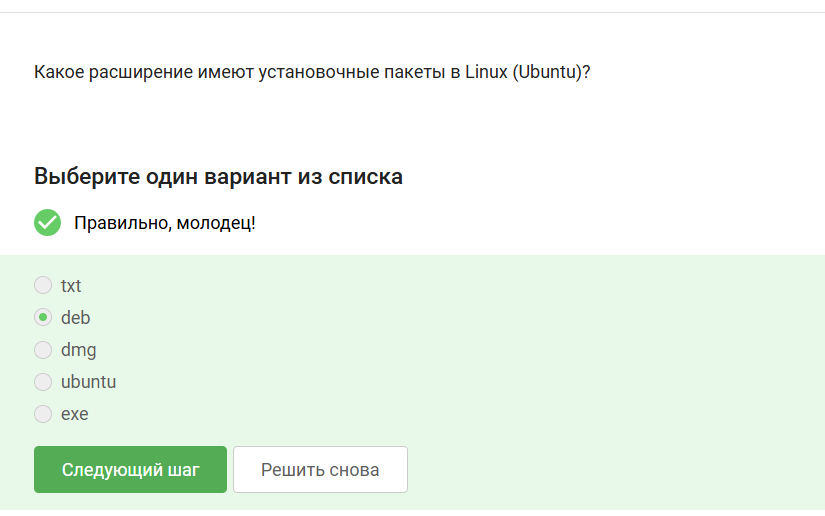

Рисунок 8: 7 задание

Я поставила себе в систему плеер VLC и посмотрела авторов (рис. 9).

[figure not shown]

Рисунок 9: 8 задание

Фамилия первого автора - Denis-Courmont (рис. 10).

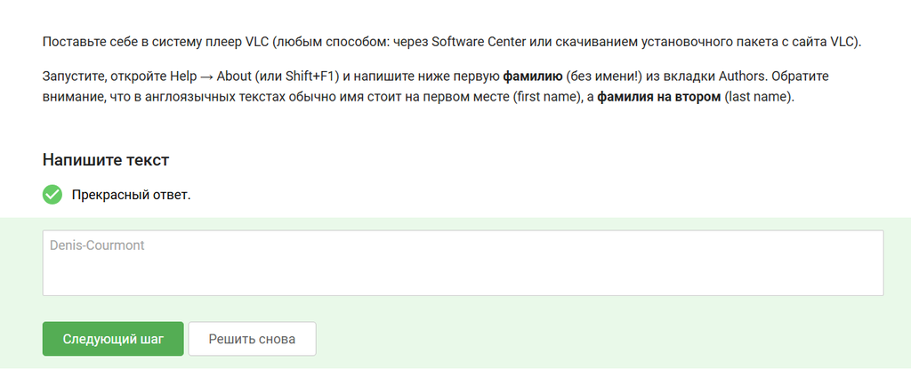

Рисунок 10: 8 задание

Update Manager - программа для обновления установленного ПО в дистрибутивах линукса, основанных на Debian или использующих систему управления пакетами APT. Update Manager следит за обновлением установленных программ, всей системы и ссылок в Software Center. Установка или удаление - это не его задачи (рис. 11).

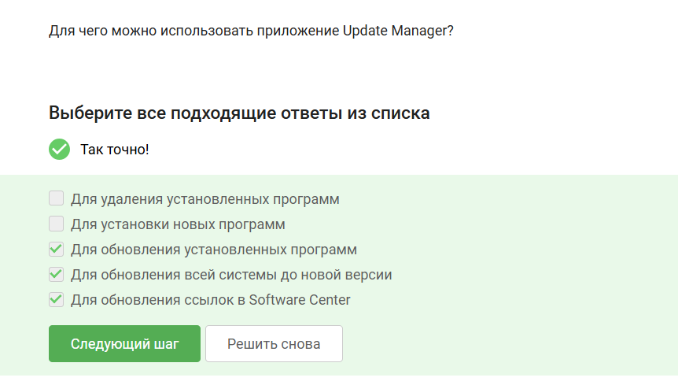

Рисунок 11: 9 задание

Ассоль - женское имя, термин - определение, терминал и консоль - синонимы к командной строке (рис. 12).

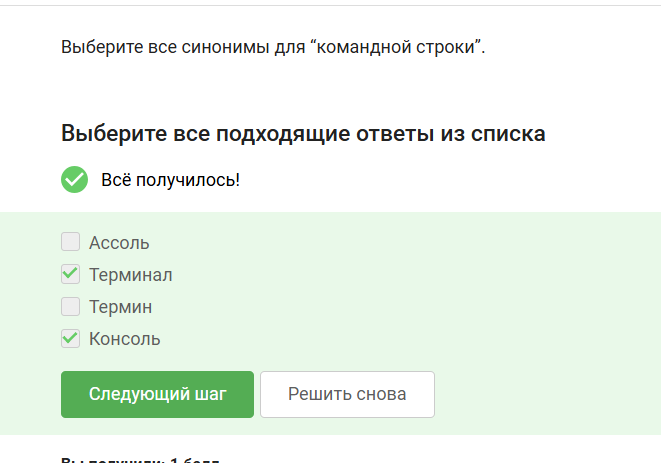

Рисунок 12: 10 задание

Только pwd. PWD и Pwd не сработают, потому что регистр важен (рис. 13).

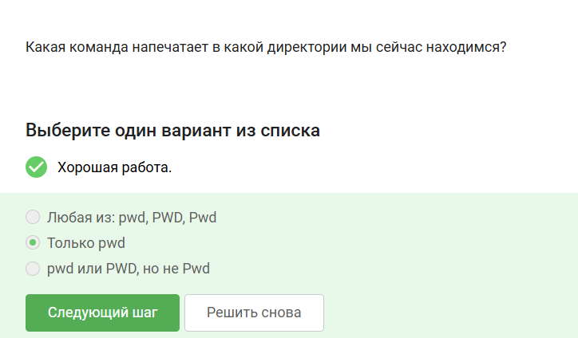

Рисунок 13: 11 задание

Все варианты кроме последнего являются верными, потому что в последнем нет аргумента /some/directory (рис. 14).

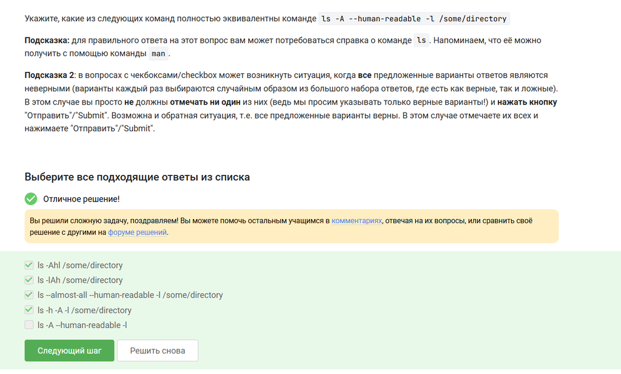

Рисунок 14: 12 задание

Все команды верные и ведут в нужную папку (рис. 15).

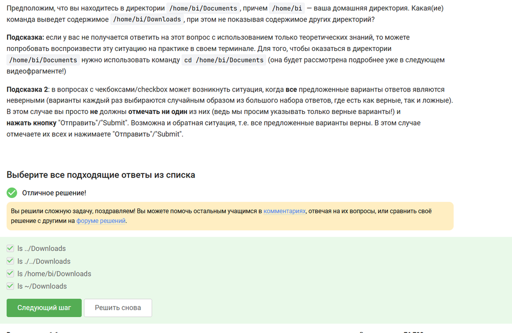

Рисунок 15: 13 задание

rm -r - удаление директорий рекурсивно, mkdir - создание директорий, mkdir -r - вызовет ошибку, rm -f - удаляет файлы (рис. 16).

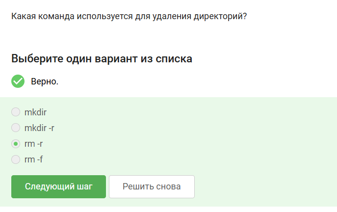

Рисунок 16: 14 задание

Терминал зависает в ожидании Firefox, exit не срабатывает, Firefox не закрывается (рис. 17).

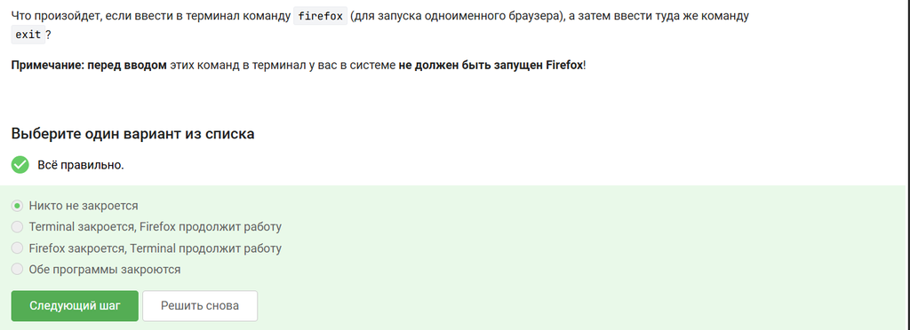

Рисунок 17: 15 задание

& - запуск в фоновом режиме. Ctrl+Z остонавливает, bg продолжает в фоне (рис. 18).

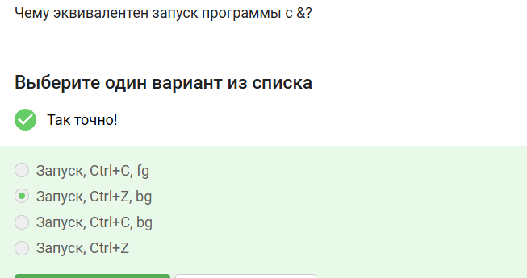

Рисунок 18: 16 задание

Я скачала файл и запустила его у себя в вм (рис. 19).

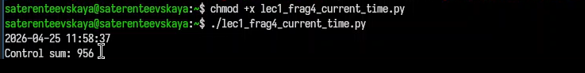

Рисунок 19: 17 задание

Вывод вписала в Stepik (рис. 20).

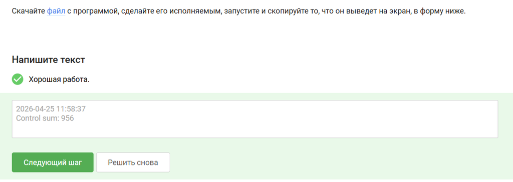

Рисунок 20: 17 задание

Stderr и stdout по умолчанию выводятся на экран (рис. 21).

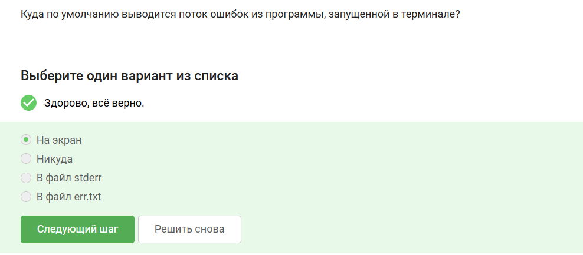

Рисунок 21: 18 задание

2> и 2>> перенаправляют stderr и создают файл file.txt, остальное либо не туда, либо не создает файл (рис. 22).

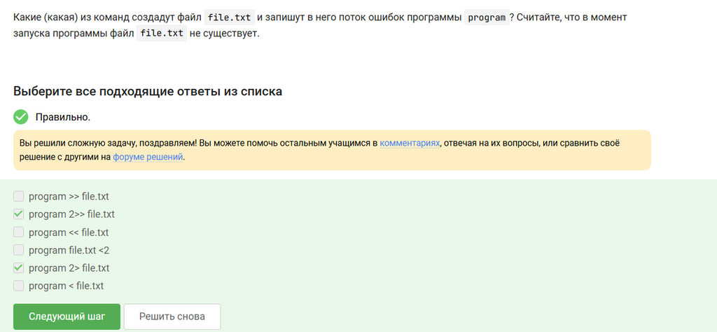

Рисунок 22: 19 задание

Автоматически поток ошибок выводится на экран, например, в ходе выполнения лабораторых работ. В файл поток выводится только, если его туда перенапрвить (рис. 23).

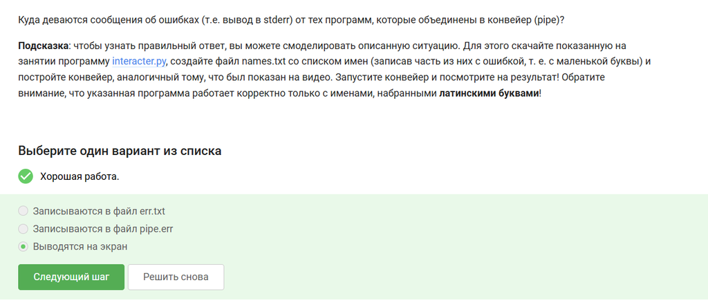

Рисунок 23: 20 задание

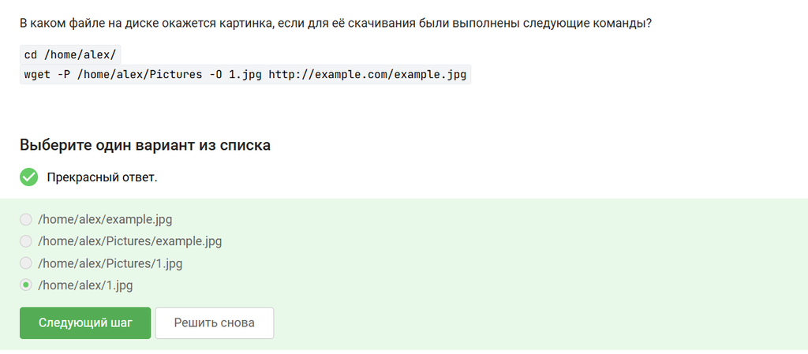

Рисунок 24: 21 задание

-q (–quiet) подавляет вывод, -v включает подробный вывод, -nv отключает подробный вывод, но не все, остаются сообщения об ошибках и прогрессе (рис. 25).

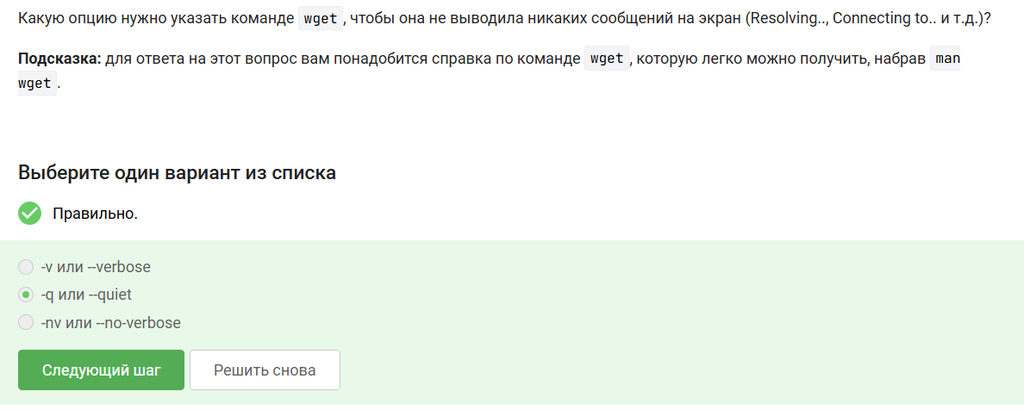

Рисунок 25: 22 задание

-A jpg ограничивает загрузку, но wget качает html для рекурсии, потом удаляет (рис. 26).

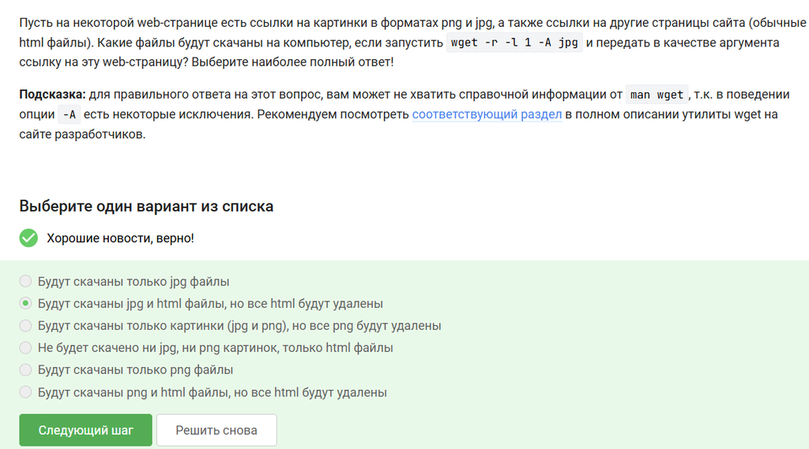

Рисунок 26: 24 задание

gunzip file gz - распаковывает файл file.gz,оставляя file.zip, а исходный file.gz удаляет. unzip file.zip распаковывает содержимое, исходный file.zip остается на месте (рис. 27).

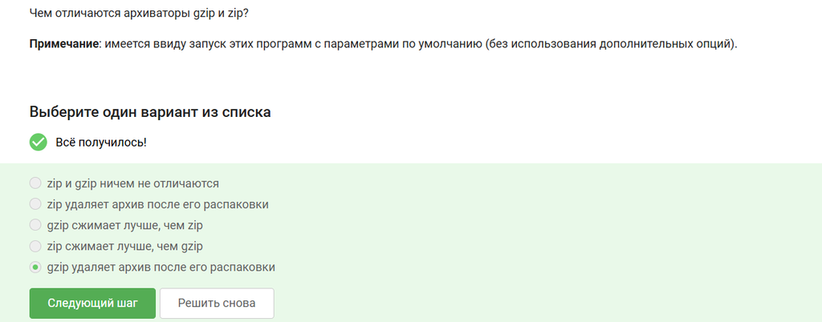

Рисунок 27: 25 задание

gzip сжимает только один файл, если применить его к директории, то выдаст ошибку (рис. 28).

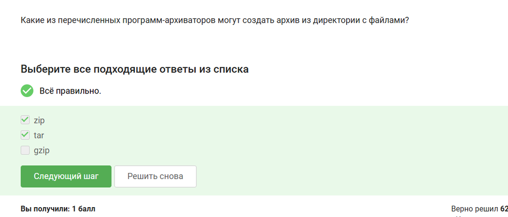

Рисунок 28: 26 задание

c — create (создать архив), j — использовать сжатие bzip2 (отсюда расширение .bz2), f — file (следующий аргумент — имя файла архива)